# Modeling a Numeric Outcome

This lab provides and introduction to *supervised learning*, the process of modeling an outcome variable. It will focus on numerical outcomes, and future labs will cover categorical outcomes.

**Directions** (Please read before starting)

1. Please *work together* with your assigned partner. Make sure you both fully understand each concept before you move on.
2. Please record your answers and any related code for all embedded lab questions. I encourage you to try out the embedded examples, but you shouldn’t turn them in.
3. Please ask for help, clarification, or even just a check-in if anything seems unclear.

$~$

## Preamble

### Packages and Datasets

This lab will use the implementation of $k$-nearest neighbors in the `FNN` package.

```r
# load the following packages
# install.packages("FNN")
library(FNN)
library(ggplot2)
library(dplyr)
```

$~$

### Supervised vs. Unsupervised Learning

Previous labs have covered PCA and clustering, which are **unsupervised learning** approaches that do not require the data analyst to specify an outcome variable.

Scenarios with a pre-determined outcome variable are called **supervised learning** tasks. In this setting, we’ll adopt the following modeling framework:
$$Y =
f(\mathbf{X}) + \epsilon$$

- $Y$ is the outcome variable
- $f()$ is an unknown function of $\mathbf{X}$ (a matrix of input variables)
- $\epsilon$ is a random error term that is independent of $\mathbf{X}$ and has a mean of zero

Thus, the outcome variable is modeled by a *systematic component*, which uses the information in $\mathbf{X}$, and *error*, which is sometimes described as *noise*.

$~$

### Reasons for Supervised Learning

**Reason #1 - Prediction:**

- Using existing data, $\{Y,\mathbf{X}\}$, we estimate $f()$ as $\hat{f}()$.
  - We want to use $\hat{f}()$ to accurately predict unknown outcomes, $Y_{\text{new}}$, for new data, $\mathbf{X}_\text{new}$
- If our estimate, $\hat{f}()$, results in a good model, our predictions, $\hat{Y}_{\text{new}}$ will be close to the truth, $Y_{\text{new}}$

**Reason #2 - Inference:**

- We estimate $\hat{f}()$ with the goal of understanding the relationship between predictors (columns of $\mathbf{X}$) and the outcome
  - Which predictors are associated with the outcome?
  - How strong are these relationships?
  - Can these relationships be summarized by linear equations, or are they more complicated?
- We still want the model’s predictions to be reasonably good, but we also want the model to be interpretable

$~$

### Example

The data frame `rmr` contains the body weights (lbs) and resting metabolic rates (kcal/day) for a random sample of $n = 44$ US adult women. Before modeling, we should always explore the data using visualization, descriptive statistics, or methods like PCA/clustering:

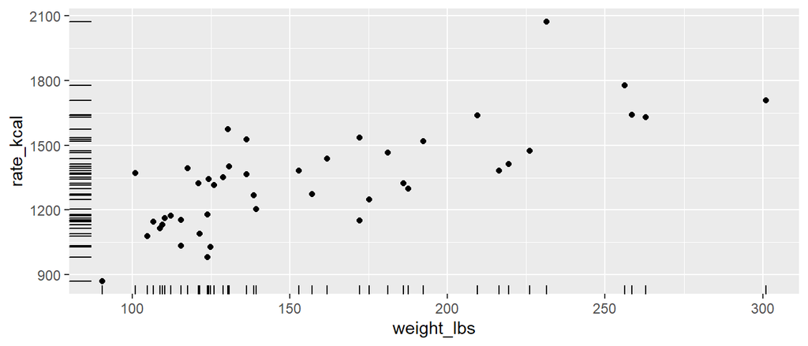

```r
rmr <- read.csv("https://remiller1450.github.io/data/RMR.csv")
ggplot(rmr, aes(x = weight_lbs, y = rate_kcal)) + geom_point() + geom_rug()
```

There’s a clear relationship between body weight and RMR, so let’s visualize a few different models for these data. What are some advantages/disadvantages you see?

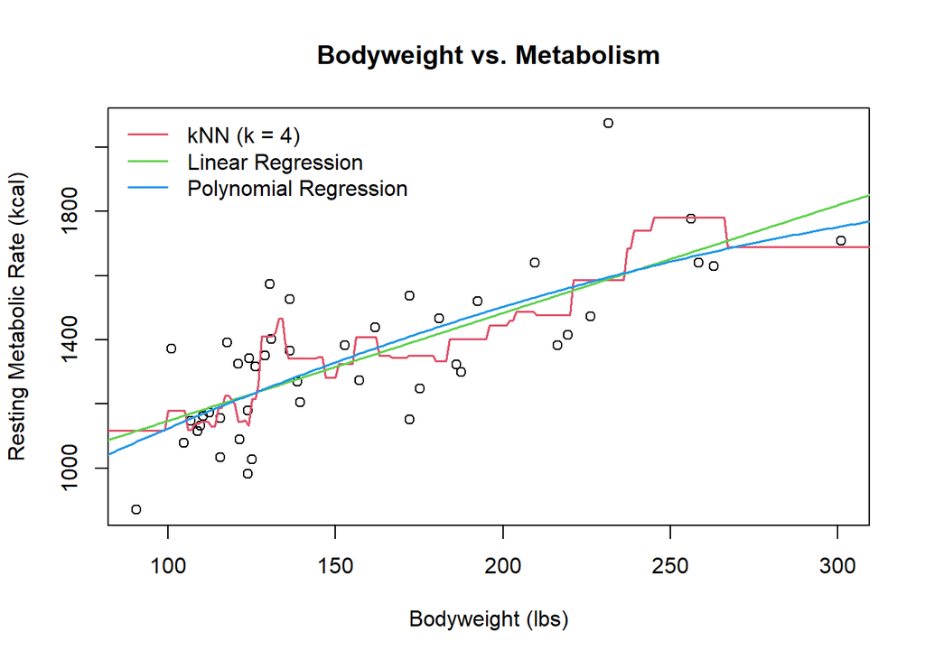

If you’re curious, here are more detailed descriptions of each model:

1. $k$-nearest neighbors - the predicted RMR at a given body weight is the average observed RMR of $k$ nearest data-points
2. Linear regression - the predicted RMR is represented by the *line* whose predicted values, $\hat{Y}$, have minimum squared distance from the observed outcomes, $Y$
3. Polynomial regression - the predicted RMR is represented by the *polynomial curve* whose predicted values, $\hat{Y}$, have minimum squared distance from the observed outcomes, $Y$

$~$

## Lab

### $k$-nearest Neighbors

$k$-nearest neighbors (kNN) is a simple **non-parametric model**, meaning the analyst doesn’t need to specify a functional form of $f()$. This provides flexibility to detect non-linearity and localized patterns.

**kNN Algorithm**:

Standardizing $\mathbf{X}$ is an important preliminary step in $k$-nearest neighbors. Because neighbors are found using *distance*, all variables should be on the same scale.

Next, consider a grid of *target values*, or points in the $p$-dimensional space corresponding to $\mathbf{X}$ that we’d like the model to predict.

1. For each *target value*, calculate its distance from each observation in $\mathbf{X}$
2. Sort these distances from smallest to largest
3. Select $k$ data-points in order of smallest distance
4. Aggregate the observed $y$ values of the selected data-points to obtain a predicted $Y$ value (either a simple average, or inverse distance weighted average)

$~$

#### R Implementation

Using $k$-nearest neighbors involves two steps:

1. Identifying the grid of target values (ie: what is the space that you’d like predictions for)
2. Finding the nearest neighbors to generate predictions over this grid

The code below demonstrates these steps:

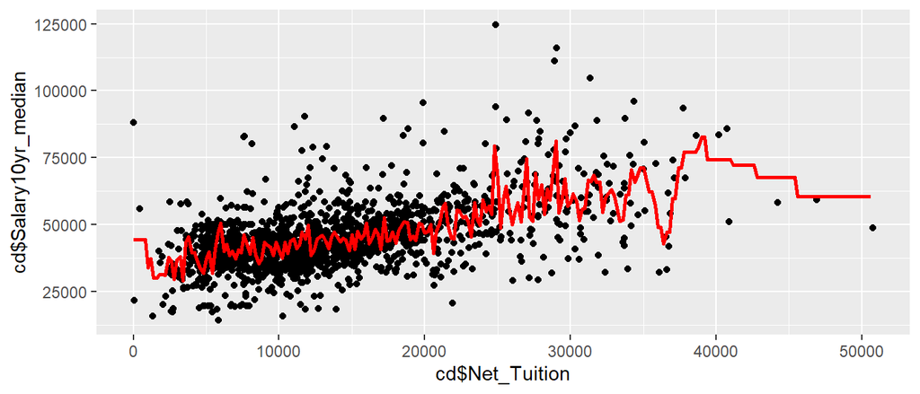

```r
colleges <- read.csv("https://remiller1450.github.io/data/Colleges2019.csv")
cd <- filter(colleges, !is.na(Salary10yr_median))

## Step #1
target_grid <- data.frame(X = seq(min(cd$Net_Tuition),
                                  max(cd$Net_Tuition), by = 200))

## Step #2
kn_fit <- knn.reg(train = cd$Net_Tuition, ## Observed x-values
               test = target_grid,        ## Target values to predict over
               y = cd$Salary10yr_median,  ## Observed y-values
               k = 5)                     ## Choice of k

## Data frame of targets w/ predicted outcomes
res <- data.frame(X = target_grid$X, Y = kn_fit$pred)

## Graph the results
ggplot() +
  geom_point(aes(x = cd$Net_Tuition, y = cd$Salary10yr_median)) +
  geom_line(aes(x = res$X, y = res$Y), col = "red", lwd = 1)
```

**Question #2**: Modify the above code so that $Y$ values are predicted using the nearest $k=15$ neighbors. Then, briefly describe the visual changes you observe for this new model compared to smaller values of $k$.

$~$

#### Choosing $k$

Similar to $k$-means clustering, an analyst using kNN must specify a value of $k$ at the start of the algorithm, and the optimal value of $k$ will vary across different applications.

- A larger value of $k$ (using more neighbors) *increases stability* (ie: less potential for overfitting) but also *increases bias* (ie: reduced ability to detect local patterns in the data)
- A smaller value of $k$ (using fewer neighbors) will *decrease bias* but also *decrease stability*

In our next lab we’ll learn about **cross-validation** as a method for choosing $k$. For now, we’ll naively base our selection on a metric called *in-sample* $RMSE$:
$$RMSE = \sqrt{\tfrac{1}{n}\sum_{i=1}^n (y_i -
\hat{y}_i)^2}$$

This measure can be described as the *average prediction error* of the model on the observed data. Because we’d like predictions to be as close to the truth as possible (smaller errors), a *lower* $RMSE$ suggests a *better model*.

The code below demonstrates how to calculate the *in-sample* $RMSE$ of a $k$-nearest neighbors model:

```r
## To find RMSE we need predictions for the observed X-values
kn_fit <- knn.reg(train = cd$Net_Tuition,         ## Observed x-values
               test = data.frame(cd$Net_Tuition), ## Target values to predict over
               y = cd$Salary10yr_median,          ## Observed y-values
               k = 5)                             ## Choice of k

## Sample size
n <- nrow(cd)

## RMSE calculation
rmse <- sqrt(1/n*sum((cd$Salary10yr_median - kn_fit$pred)^2))
rmse
```

```
## [1] 9033.458
```

So, this model’s predictions of median 10-year salary are off by around $9000 (on average).

Recognize that decreasing $k$ will *always* lead to a lower *in-sample* $RMSE$, so we might consider using something like the elbow method to choose $k$. We’ll soon discuss *out-of-sample* $RMSE$ (estimated via *cross-validation*), which does not have this problem. Additionally, you might also use $k \approx \sqrt{n}$, which is a commonly used rule of thumb.

$~$

#### Practice with kNN

**Question #3 (Part A)**: Using the resting metabolism data, fit a $k$-nearest neighbors model with $k = 7$ (approximately $k = \sqrt{n}$). Plot the predictions from this model over a grid of body weights that encompasses the full range seen in the observed data.

**Question #3 (Part B)** Find the *in-sample* $RMSE$ of the model from Part A. Provide a brief interpretation of this quantity.

**Question #3 (Part C)**: Fit another $k$-nearest neighbors model with $k = 3$ find its corresponding *in-sample* $RMSE$. Which of these two models (using $k = 7$ and $k = 3$) fits the observed data more closely? Do you have any concerns relying upon the better fitting model?

$~$

### Linear Regression

$k$-nearest neighbors is an example of a highly flexible model that does not make many assumptions about $f()$, the modeling component that systematically maps input variables to output values. Regression modeling lies on the other end of the spectrum, as it makes fairly strong assumptions about $f()$.

More specifically, the term “linear regression” describes a *class of models* that are:

1. **parametric** - they use a pre-specified functional form of $f()$
2. **statistical** - they use a pre-specified probability distribution for $\epsilon$, the error term

For a *population of interest*, simple linear regression assumes a straight-line relationship between two variables in this population. This population-level model is expressed using the following parametric structure:
$$Y = \beta_0 +
\beta_1X + \epsilon$$

- $Y$ is the *outcome* variable
- $X$ is the *independent* or *explanatory* variable
- The intercept and slope, $\beta_0$ and $\beta_1$, are *parameters* of the model (making it a parametric model)
- $\epsilon$ is a random error (making it a statistical model)

The random errors, $\epsilon$, follow a $N(0, \sigma^2)$ distribution that is independent of $X$. This means that errors should be identically distributed across the entire range of $X$:

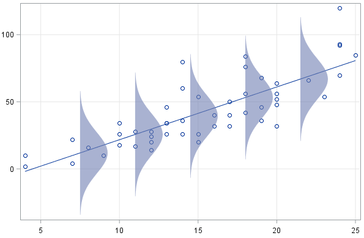

Because we’ll never have data on an entire population, using linear regression involves two steps:

1. **Model Specification** - describing the model *at the population level*, for example: $\text{Metabolism} = \beta_0 + \beta_1 \text{Weight} + \epsilon$ for *all US adult women*
2. **Model Fitting** - using the *sample data* to *estimate* the model’s unknown parameters (ie: estimate the numeric values of $\beta_0$ and $\beta_1$)

In most circumstances, [ordinary least squares](https://www.jmp.com/en_hk/statistics-knowledge-portal/what-is-multiple-regression/fitting-multiple-regression-model.html) is used to estimate the unknown parameters of a linear regression model from sample data:

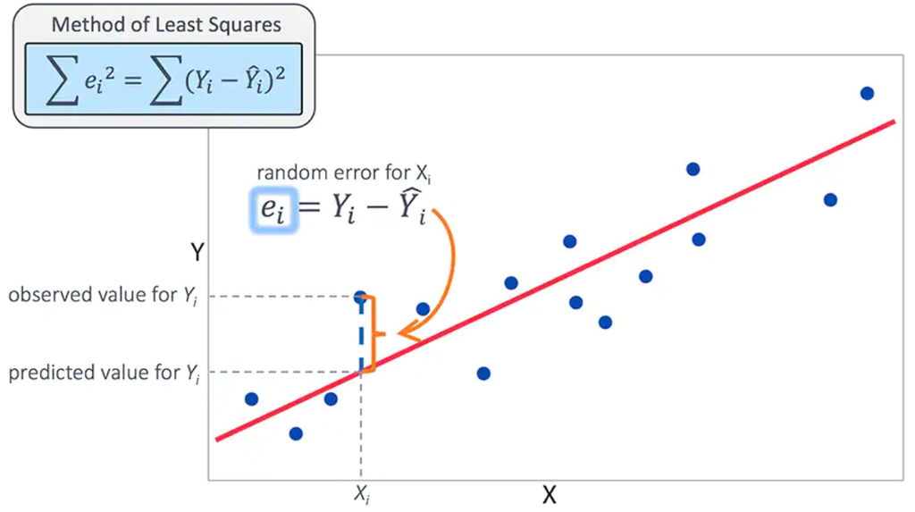

Least squares solves for the combination of model parameters that minimize *in-sample* $RMSE$.

In `R`, the model specification step is done using a **formula**, while model fitting step is done using the `lm()` function:

```r
## Model specification
my_form <- formula(rate_kcal ~ weight_lbs)

## Model fitting
lm_fit <- lm(my_form, data = rmr)
coefficients(lm_fit)
```

```
## (Intercept)  weight_lbs
##   811.22667     3.36168
```

For the resting metabolism data, we estimate (using these $n = 44$ women) that each 1 pound increase in body weight is associated with a 3.36 kcal per day increase in resting metabolic rate.

Note that we could also specify the model’s formula directly inside the `lm()` function:

```r
lm_fit <- lm(rate_kcal ~ weight_lbs, data = rmr)
coefficients(lm_fit)
```

```
## (Intercept)  weight_lbs
##   811.22667     3.36168
```

**Question #4**: For this question, consider a *multiple linear regression* model where the median 10-year salary of a college’s alumni is expressed as a linear combination of the school’s admissions rate and net tuition. We will estimate this model using college scorecard data from 2019, stored in `cd`.

```r
colleges <- read.csv("https://remiller1450.github.io/data/Colleges2019.csv")
cd <- filter(colleges, !is.na(Salary10yr_median), !is.na(Adm_Rate), !is.na(Net_Tuition))
```

**Part A**: Write out the *population-level* model for this scenario. *Hint*: `R` is not necessary for this part.

**Part B**: Use the `lm()` function to estimate this model using the 2019 college scorecard data. Interpret each of the estimated slopes.

**Part C**: The `lm()` function returns a list object that contains a vector named “fitted.values” (ie: predicted $y$-values). Use this vector to calculate the model’s *in-sample* $RMSE$.

*Note*: In Part C, the *in-sample* $RMSE$ will be close to the “Residual standard error” reported when using the `summary()` function on the fitted model, but $RMSE$ uses $\tfrac{1}{n}$ while residual SE standard error uses $\tfrac{1}{n-p}$ (where $p$ is the number of model parameters)

$~$

#### Predictions and Graphs

Models fit using `lm()` have a built-in prediction routine that can help us generate graphics:

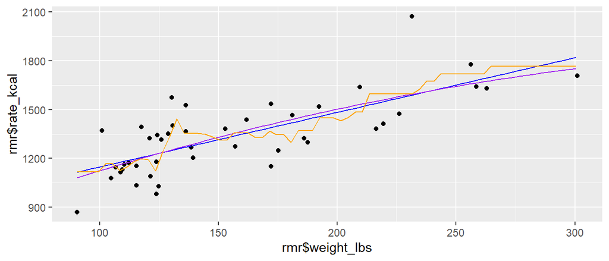

```r
## Model fit #1
lm_fit <- lm(rate_kcal ~ weight_lbs, data = rmr)

## Grid of X to predict over
weight_grid <- data.frame(weight_lbs = seq(min(rmr$weight_lbs), max(rmr$weight_lbs), by = 3))

## Predicted Y values for the grid (lm model)
lm_preds <- predict(lm_fit, newdata = weight_grid)

## Model fit #2
poly_fit <- lm(rate_kcal ~ poly(weight_lbs, degree = 2), data = rmr)
poly_preds <- predict(poly_fit, newdata = weight_grid)

## Model fit #3
kn_fit <- knn.reg(train = rmr$weight_lbs, test = weight_grid,
                 y = rmr$rate_kcal, k = 5)
kn_preds <- kn_fit$pred  ## Note that there is no predict routine for knn

## Graph both models
ggplot() +
   geom_point(aes(x = rmr$weight_lbs, y = rmr$rate_kcal)) +
   geom_line(aes(x = weight_grid$weight_lbs, y = lm_preds), color = "blue") +
   geom_line(aes(x = weight_grid$weight_lbs, y = poly_preds), color = "purple") +
   geom_line(aes(x = weight_grid$weight_lbs, y = kn_preds), color = "orange")
```

To create a graph like the one above for a model with more than one explanatory variable, we must decide how to handle the explanatory variables that will not be displayed. A common strategy is to hold these variables at their median value (or the most common category for categorical predictors):

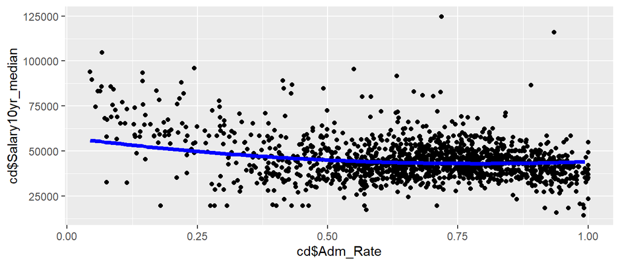

```r
## Example (colleges data)
colleges <- read.csv("https://remiller1450.github.io/data/Colleges2019.csv")
cd <- filter(colleges, !is.na(Salary10yr_median), !is.na(Adm_Rate), !is.na(Net_Tuition))

## Model fit
lm_fit <- lm(Salary10yr_median ~ poly(Adm_Rate, degree = 2) + Net_Tuition, data = cd)

## Grid of X to predict over
Adm_grid <- data.frame(Adm_Rate = seq(min(cd$Adm_Rate), max(cd$Adm_Rate), by = 0.01),
                          Net_Tuition = median(cd$Net_Tuition))

## Predictions
Adm_preds <- predict(lm_fit, newdata = Adm_grid)

## Graph
ggplot() +
   geom_point(aes(x = cd$Adm_Rate, y = cd$Salary10yr_median)) +
   geom_line(aes(x = Adm_grid$Adm_Rate, y = Adm_preds), color = "blue", lwd = 1.5)
```

*Note*: The example code above exploits the *recycling rule* when creating `Adm_grid`. Because `median(cd$Net_Tuition)` is a single number, it gets recycled (repeated) to match the length of `Adm_Rate` sequence stored in the same data frame.

**Question #5**: Fit a linear regression model that uses “Cost” and a third-degree polynomial representation of “Enrollment” to predict “Avg_Fac_Salary”. Then, create a graph displaying the model’s estimated relationship between “Enrollment” and “Avg_Fac_Salary” while holding “Cost” at its median value.

```r
colleges <- read.csv("https://remiller1450.github.io/data/Colleges2019.csv")
cd <- filter(colleges, !is.na(Avg_Fac_Salary), !is.na(Cost), !is.na(Enrollment))
```

$~$

### Practice

**Question #6**: For this question you will conduct a comprehensive analysis using the AFQT data introduced below.

The [Armed Forces Qualification Test (AFQT)](https://en.wikipedia.org/wiki/Armed_Services_Vocational_Aptitude_Battery) is a multiple choice aptitude test designed to measure whether an individual’s reasoning and verbal skills are sufficient for military service. Because the test has been so broadly applied, percentile scores are frequently used as a measure of general intelligence.

The `afqt` data set is a random sample of $n = 2584$ Americans who were first selected and tested in 1979, then later re-interviewed in 2006 and asked about their education and annual income. The focus of this analysis will be modeling 2005 incomes using AFQT scores (from 1979) with and without adjusting for educational attainment.

```r
## Load the data
afqt <- read.csv("https://remiller1450.github.io/data/AFQT.csv")
```

**Part A**: Create a scatter plot displaying the relationship between AFQT percentile scores and 2005 income while coloring each point by educational attainment. Write 1-2 sentences describing the relationship (or lack thereof) between these variables.

**Part B**: Without considering educational attainment, use $k$-nearest neighbors with $k = 50$ (approximately $\sqrt{n}$) to generate predicted incomes based upon AFQT percentile. Create a graphical display of this model and report the *in-sample* $RMSE$.

**Part C**: Without considering educational attainment, use *simple linear regression* to model income in response to AFQT percentile. Create a graphical display of this model and report the *in-sample* $RMSE$.

**Part D**: Report and interpret the slope coefficient from the model in Part C.

**Part E**: Fit new linear regression model that also uses “Educ” as a predictor and report its slope. Why might this slope differ from the one in Part D? How should an interpretation of it change? *Hint*: remember that the slope coefficient for “AFQT” in this model reflects changes in the outcome as “AFQT” varies *while “Educ” is held constant*.

$~$

### Additional Resources

Modeling is an extremely broad and deep area of data science. In our next lab we’ll discuss topics related to model assessment and validation. Some other important topics that we will not cover include:

- Feature engineering
- Statistical inference on model parameters
- Interactions between explanatory variables in linear models

If you’re interested in these topics I encourage you to check out following books written by Max Kuhn and Kjell Johnson:

- [Applied Predictive Modeling](http://appliedpredictivemodeling.com/)
- [Feature Engineering](http://www.feat.engineering/)